# Análisis de Conglomerados, Encuesta Nacional de Opinión sobre TIC

Por: Ayar Yuman Paco Sanizo y Marco Antonio Vino Chipana

22 de abril de 2018

# 1. Introducción

## 1.1 Descripción del proyecto

A partir de la convocatoria del “CONCURSO SOBRE DATOS ABIERTOS Y USO DE LA ENCUESTA NACIONAL DE OPINIÓN SOBRE TIC” de la Agencia de gobierno electrónico y tecnologías de la información (AGETIC), iniciamos un proceso de exploración de la base de datos a fin de identificar un producto adecuado. En este proceso se identificó una gran cantidad de variables con valores perdidos que dificultaría y afectaría la representatividad de cualquier análisis posterior. Por tanto, se planteó un procedimiento de imputación que dio como resultado una base de datos reducida respecto a las variables que mantiene el total de observaciones. Por otra parte, se identificó una gran cantidad de variables categóricas en contraste a la cantidad de variables numéricas. Finalizada la exploración, se encuentró útil identificar conglomerados entre los encuestados respecto a la temática de las TIC.

Bajo esta linea inicialmente se trato de identificar variables que permitan discriminar conglomerados considerando teorías económicas. Sin embargo esta era una tarea laboriosa y en muchos casos no se identificaban diferencias marcadas entre los conglomerados. Por tanto decidimos considerar un problema de aprendizaje no supervisado tomando una gran cantidad de variables para que bajo una perspectiva multivariante se puedan identificar conglomerados que esten considerablemente separados. El modelo elegido para este fin fue K-Prototypes, una combinación de K-means y K-modes, que permite considerar variables categóricas y numéricas.

Una vez identificados los conglomerados resultaba importante seleccionar las variables más importantes en su definición. Es decir, encontrar las variables que permitan identificarlos con mayor facilidad. De esta forma se consideró un problema de aprendizaje supervisado para identificar las variables más importantes a la hora de predecir la pertencia de las observaciones a los conglomerados. Para esta tarea se consideró el modelo Random Forest por la facilidad que tiene para identificar variables importantes. Luego, tomando estas variables se volvieron a identificar conglomerados para finalmente realizar un análisis descriptivo cruzado respecto a las variables que ingresaron al modelo final y a otras de interés para la interpretación de los conglomerados.

## 1.2 Objetivos

### 1.2.1 Objetivo General

- Identificar conglomerados entre las personas encuestadas en la Encuesta Nacional de Opinión sobre TIC y describir su comportamiento.

### 1.2.2 Objetivos Específicos

- Pre-procesar la base de datos de la Encuesta Nacional de Opinión sobre TIC para poder identificar conglomerados representativos entre los encuestados.
- Identificar conglomerados en la base de datos considerando variables categóricas y numéricas representativas.
- Identificar las variables más importantes que permitan una mejor identificación de los conglomerados.
- Realizar un análisis descriptivo de los conglomerados respecto a las variables que mejor los definen.
- Realizar un análisis descriptivo de los conglomerados respecto a otras variables de interés.
- Definir perfiles conceptuales de los conglomerados identificados.

## 1.3 Consideraciones

Es imporante notar que el presente proyecto tiene como resultado un análisis descriptivo de la muestra respecto a los conglomerados identificados. Esto es, no se puede asegurar que los resultados reflejen a la población. Este tratamiento inferencial es una tarea posterior que requiere un análisis minucioso considerando el método de muestreo usado en la encuesta.

# 2. Pre-procesamiento

A continuación se describe la etapa de pre-procesamiento de la base de datos. Partimos describiendo el análisis de valores faltantes, luego el proceso de imputación y finalmente la pre-selección de variables para la etapa de modelación.

## 2.1 Análisis de valores faltantes

Empezando el análsisis mapeamos los valores faltantes para tener una idea visual de la cantidad de datos perdidos en la encuesta. En esta primera etapa solo se consideran como valores faltantes a las celdas vacias. Esto es, aún no se consideran como faltantes a las celdas con codificaciones correspondientes a la etiqueta “No sabe/No responde”. Este tratamiento se efectuará posteriomente.

En el siguiente gráfico, en el eje vertical tenemos filas y en horizontal columnas de la base de datos. Las celdas con observaciones tienen un color guindo mientras que las celdas vacias tienen color beige. A partir de este mapeo se indentifica que de las 451 variables, la gran mayoría tiene bastantes datos faltantes.

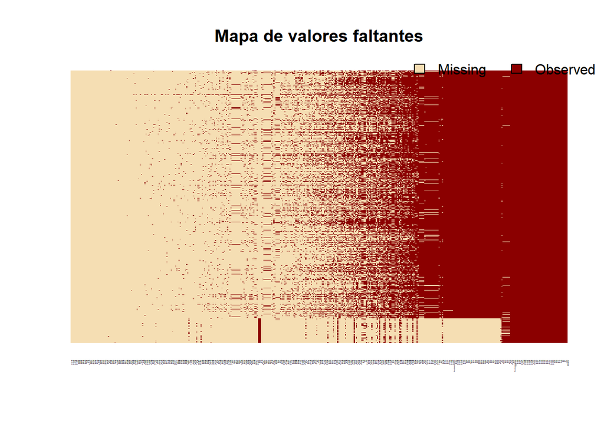

A continuación ordenamos las variables de la base de datos respecto a su porcentaje de valores perdidos y consideramos únicamente las variables que tienen hasta un 5% de valores faltantes como máximo. Las variables que pasan este filtro son:

```
##  [1] "NUMBOL"         "Tipo"           "P1"             "P2"
##  [5] "P4"             "P6"             "P10"            "P12"
##  [9] "P14"            "P15A"           "P16"            "P17"
## [13] "P20"            "P23"            "P28"            "P30"
## [17] "P31A"           "P32"            "P33"            "P34"
## [21] "P35"            "P36A"           "P129A"          "P130A"
## [25] "P131A"          "P132A"          "P133A"          "P134"
## [29] "P135"           "P136"           "P137"           "P138"
## [33] "P139"           "P140"           "P148"           "P149"
## [37] "P150"           "P151"           "P152"           "P153"
## [41] "P154A"          "P155"           "P156A"          "P156B"
## [45] "P156C"          "P156D"          "P156E"          "P156F"
## [49] "P156G"          "P156H"          "P156I"          "P156J"
## [53] "P156K"          "P157"           "P158"           "P159"
## [57] "P160"           "CodP160"        "Ponderador5536" "Nse"
```

Luego filtrando la base de datos con estas 60 variables y volviendo a mapear los valores faltantes obtenemos el siguiente mapeo de valores faltantes.

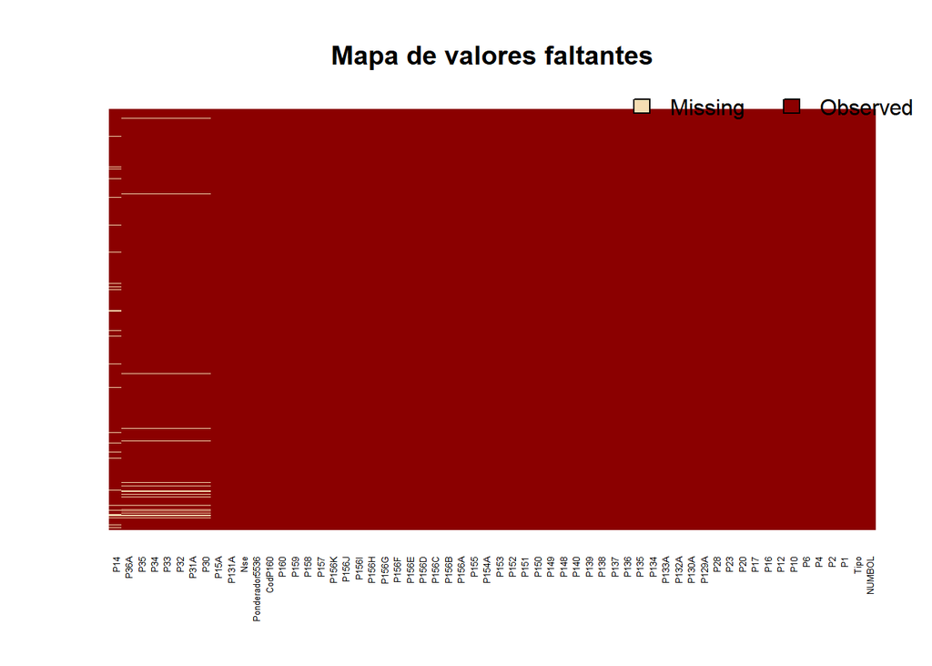

## 2.2 Definición de tipos de variables y codificación de valores perdidos

Ahora, si bien al parecer la base de datos resultante tiene pocos datos faltantes, debemos considerar que varias variables tienen codificaciones para la etiqueta “No sabe/No responde”. Por tanto, resulta importante no solo definir si una variable es categorica o numerica, sino también codificar adecuadamente estas etiquetas como valores perdidos.

Luego de efectuar este procedimiento, obtenemos el siguiente resumen de variables y el mapeo de valores faltantes actualizado.

```
##      NUMBOL      Tipo           P1        P2       P4       P6
##  Min.   :    1   1:5033   Min.   :14.00   1:5066   1:1098   1:2736
##  1st Qu.: 2023   2: 503   1st Qu.:21.00   2: 470   2:4438   2:2800
##  Median : 9066            Median :30.00
##  Mean   : 7856            Mean   :32.62
##  3rd Qu.:11298            3rd Qu.:42.00
##  Max.   :17514            Max.   :90.00
##
##       P10       P12           P14          P15A      P16      P17
##  9      :2455   1:5297   Min.   :   70   1   :3883   1:2277   1: 625
##  7      : 667   2: 239   1st Qu.: 1200   2   : 500   2:3259   2:4911
##  8      : 467            Median : 1800   3   :  98
##  3      : 444            Mean   : 2083   4   : 811
##  2      : 440            3rd Qu.: 2650   5   :  20
##  5      : 321            Max.   :21000   6   : 222
##  (Other): 742            NA's   :2276    NA's:   2
##  P20      P23      P28           P30            P31A        P32
##  1:4501   1: 572   1:5345   Min.   :  10   1      :5019   1   :4861
##  2:1035   2: 911   2: 191   1st Qu.: 600   2      :  97   2   : 436
##           3:4053            Median : 960   3      :  91   3   :  48
##                             Mean   :1117   6      :  59   NA's: 191
##                             3rd Qu.:1500   4      :  29
##                             Max.   :8001   (Other):  50
##                             NA's   :937    NA's   : 191
##    P33            P34           P35         P36A          P129A
##  1   :1820   Min.   :  1.00   1   : 127   1   :4351   1      :3951
##  2   :2650   1st Qu.: 35.00   2   : 333   2   : 169   2      : 468
##  3   : 875   Median : 70.00   3   :1479   3   :  60   6      : 450
##  NA's: 191   Mean   : 90.41   4   :2117   4   : 161   5      : 231
##              3rd Qu.:120.00   5   :1289   NA's: 795   3      : 192
##              Max.   :900.00   NA's: 191               (Other): 152
##              NA's   :249                              NA's   :  92
##      P130A          P131A          P132A          P133A
##  1      :3272   1      :2279   1      :3008   1      :1681
##  6      : 653   5      : 972   6      : 823   3      : 860
##  2      : 505   6      : 687   5      : 434   2      : 623
##  5      : 490   2      : 356   2      : 331   6      : 449
##  3      : 244   3      : 250   3      : 198   5      : 381
##  (Other): 178   (Other): 307   (Other): 226   (Other): 255
##  NA's   : 194   NA's   : 685   NA's   : 516   NA's   :1287
```

[output cut: 33 more lines]

```
##  1      :3604   1: 730   1: 267   4      :1416   4      : 741   1:2824
##  2      :1345   2:4806   2:5269   5      :1197   1      : 663   2:1306
##  3      : 296                     3      : 983   6      : 661   3:1406
##  0      : 129                     6      : 735   9      : 647
##  4      : 108                     2      : 390   2      : 615
##  5      :  39                     7      : 356   3      : 598
##  (Other):  15                     (Other): 459   (Other):1611
##          P160         CodP160     Ponderador5536    Nse
##  Cobija    : 422   16     : 422   Min.   :0.04898   1:1533
##  Santa Cruz: 420   70     : 420   1st Qu.:0.33448   2:1738
##  Sucre     : 360   78     : 360   Median :0.41612   3:1351
##  Oruro     : 308   44     : 308   Mean   :0.97589   4: 611
##  Cochabamba: 251   17     : 251   3rd Qu.:1.52909   5: 303
##  El Alto   : 244   24     : 244   Max.   :7.26183
##  (Other)   :3531   (Other):3531
```

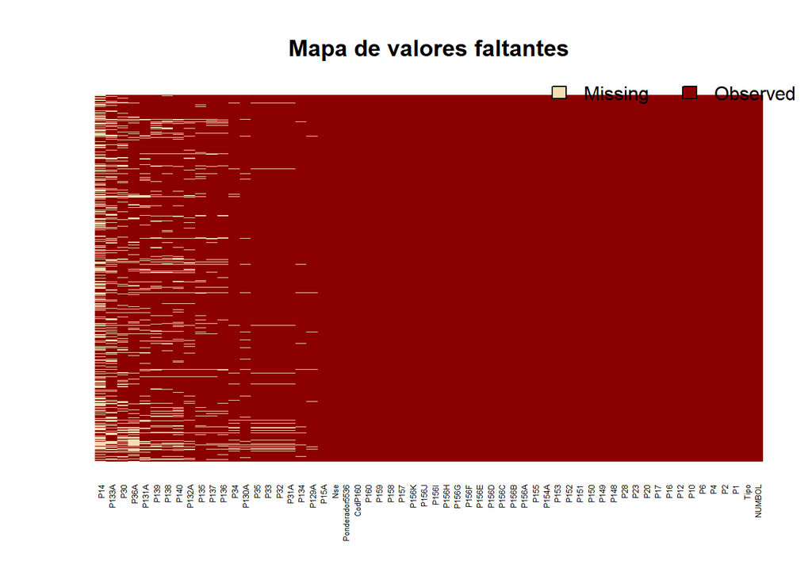

## 2.3 Imputación de datos faltantes

A partir de la base de datos resultante efectuamos un proceso de imputación para completar los valores de las variables que tienen valores perdidos. Este proceso de imputación considera dos métodos según el tipo de variable:

- Predictive mean matching (pmm), para variables cuantitativas
- Polytomous logistic regression (polyreg), para variables categóricas

Luego, los métodos de imputación correspondientes a cada variable con valores faltantes son:

```
##       P14      P15A       P30      P31A       P32       P33       P34
##     "pmm" "polyreg"     "pmm" "polyreg" "polyreg" "polyreg"     "pmm"
##       P35      P36A     P129A     P130A     P131A     P132A     P133A
## "polyreg" "polyreg" "polyreg" "polyreg" "polyreg" "polyreg" "polyreg"
##      P134      P135      P136      P137      P138      P139      P140
## "polyreg" "polyreg" "polyreg" "polyreg" "polyreg" "polyreg" "polyreg"
```

Ahora, el proceso de imputación genera cinco bases de datos imputadas. Las cinco son diferentes porque en cada caso los métodos de imputación simulan valores para los valores perdidos. De esta forma, a fin de validar este proceso de imputación, se muestran los siguientes gráficos de dispersión. En cada gráfico, el valor 0 en el eje X representa la distribución original y el resto de valores (1, 2, 3, 4 y 5) representan las distribuciones en las bases de datos imputadas, donde los puntos celestes son valores reales y los puntos rojos valores imputados. Analizando estos gráficos puede observarse que las imputaciones mantienen los comportamientos de distribución y por tanto podemos validar el procedimiento usado.

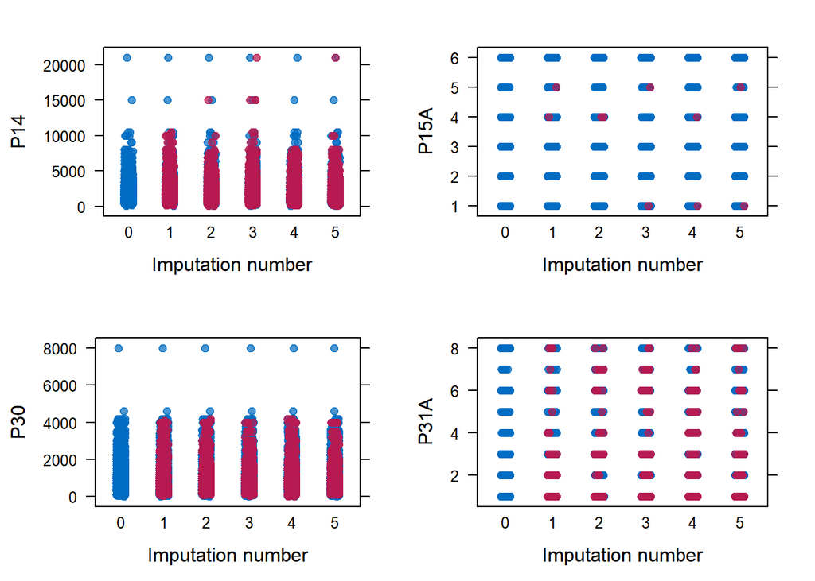

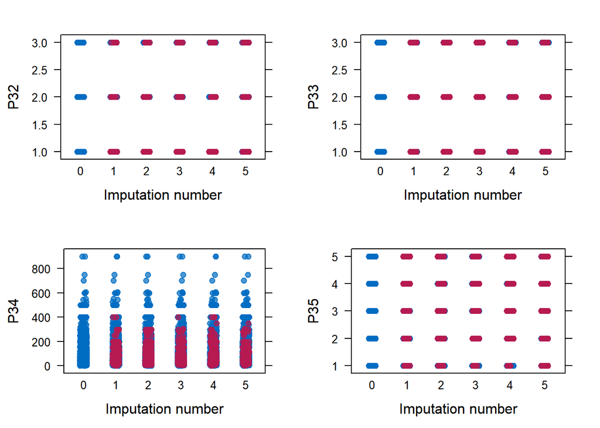

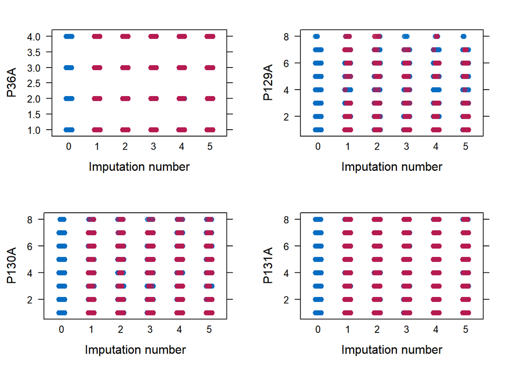

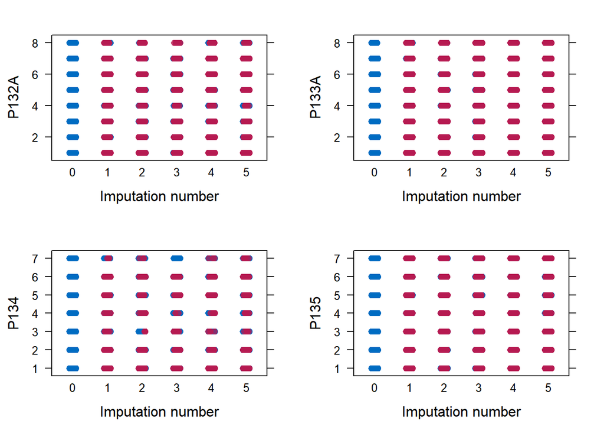

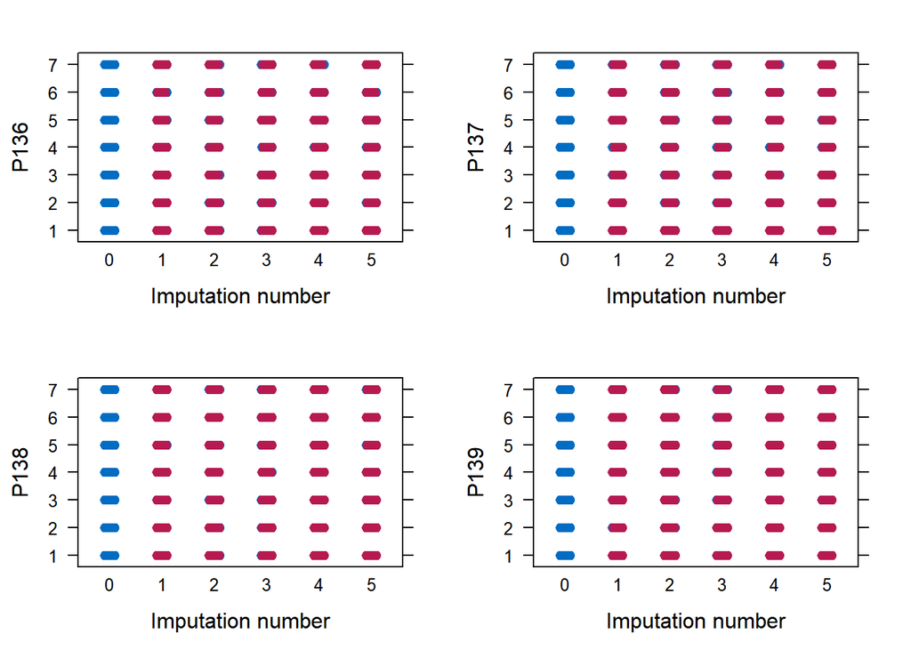

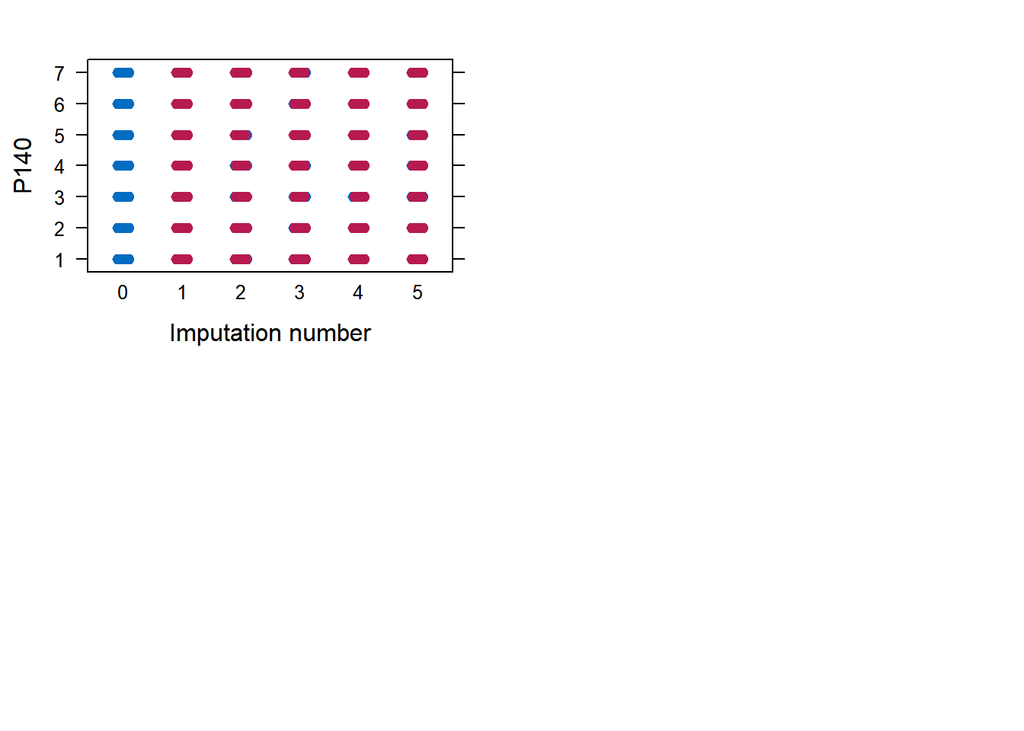

Concluido el proceso de imputación, claramente el mapeo de valores faltantes nos muestra que ya no existen valores faltantes.

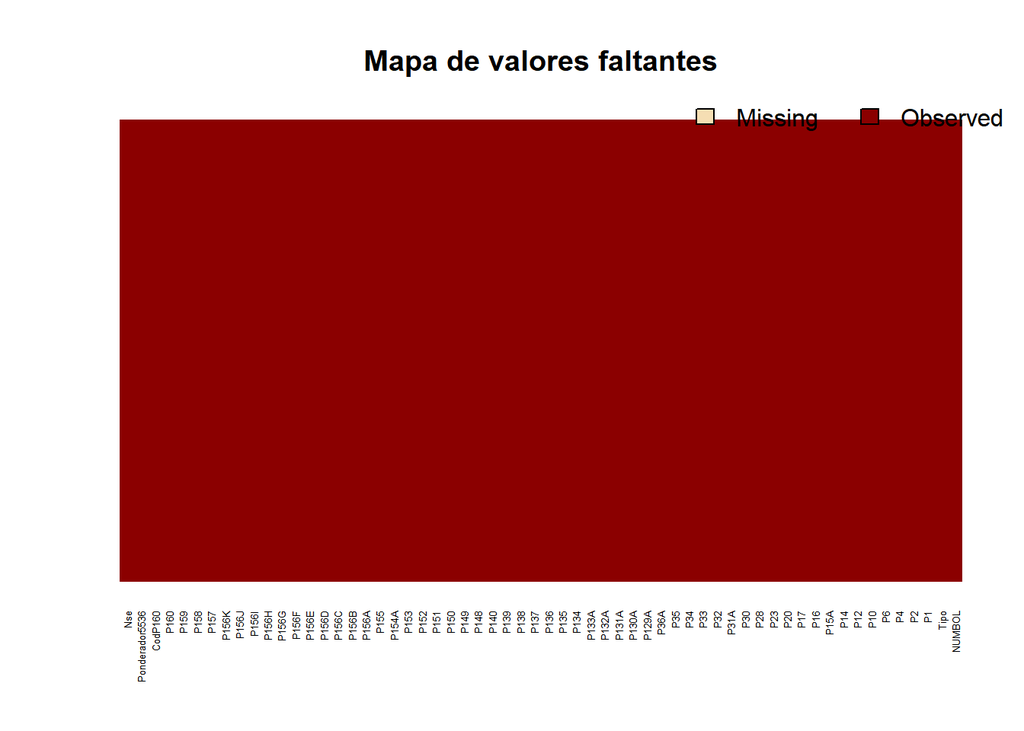

## 2.4 Pre-selección de variables para la etapa de modelación

Ahora, dado que en la etapa de modelación usaremos un modelo de conglomerados debemos dejar de lado variables que no aporten a la separación de los mismos. De esta forma, no tiene sentido considerar el número de encuestado (NUMBOL), el ponderador (Ponderador5536) ni la variable (Nse). Por otra parte, la pregunta 31 de la encuesta a internautas: ¿Qué usos le da a su celular? permite varias respuestas. Luego, la variable P31A es tan solo una de las respuestas de los encuestados y no necesariamente representa el uso más importante, y en todo caso es probable que tan solo represente el primer valor digitado en la base de datos respecto a esta pregunta. Por este motivo, tampoco resultaría beneficioso considerar la pregunta P31A. Finalmente, las variables P160 y CodP160 representan el nombre y código de las comunidades a las que pertenecen los ecuestados, cada una con un total de 97 alternativas posibles y donde en varios casos se tienen menos de 10 observaciones. Luego, este total de alternativas genera un problema técnico en la segunda etapa de modelación donde se aplicará el modelo Random Forest, motivo por el cual no se consideran ambas variables.

Tomando esta pre-selección de variables, a continuación se muestra el resumen de la base de datos que ingresará a la etapa de modelación.

```
##  Tipo           P1        P2       P4       P6            P10
##  1:5033   Min.   :14.00   1:5066   1:1098   1:2736   9      :2455
##  2: 503   1st Qu.:21.00   2: 470   2:4438   2:2800   7      : 667
##           Median :30.00                              8      : 467
##           Mean   :32.62                              3      : 444
##           3rd Qu.:42.00                              2      : 440
##           Max.   :90.00                              5      : 321
##                                                      (Other): 742
##  P12           P14        P15A     P16      P17      P20      P23
##  1:5297   Min.   :   70   1:3883   1:2277   1: 625   1:4501   1: 572
##  2: 239   1st Qu.: 1200   2: 500   2:3259   2:4911   2:1035   2: 911
##           Median : 1800   3:  98                              3:4053
##           Mean   : 2082   4: 812
##           3rd Qu.: 2650   5:  21
##           Max.   :21000   6: 222
##
##  P28           P30       P32      P33           P34         P35
##  1:5345   Min.   :  10   1:5030   1:1873   Min.   :  1.00   1: 137
##  2: 191   1st Qu.: 600   2: 450   2:2765   1st Qu.: 35.00   2: 357
##           Median : 950   3:  56   3: 898   Median : 70.00   3:1533
##           Mean   :1102                     Mean   : 89.99   4:2175
##           3rd Qu.:1500                     3rd Qu.:120.00   5:1334
##           Max.   :8001                     Max.   :900.00
##
##  P36A         P129A          P130A          P131A          P132A
##  1:4846   1      :4004   1      :3383   1      :2572   1      :3294
##  2: 216   2      : 479   6      : 670   5      :1062   6      : 895
##  3: 116   6      : 456   2      : 529   6      : 790   5      : 465
##  4: 358   5      : 234   5      : 503   2      : 420   2      : 386
##           3      : 198   3      : 251   3      : 292   3      : 225
##           4      : 108   4      : 145   4      : 268   7      : 153
##           (Other):  57   (Other):  55   (Other): 132   (Other): 118
##      P133A      P134     P135     P136     P137     P138     P139
##  1      :2191   1:2734   1:2713   1:2662   1:2808   1:2013   1:2398
##  3      :1049   2: 647   2: 971   2: 927   2: 874   2:1095   2: 835
##  2      : 813   3: 119   3: 640   3:1109   3: 792   3: 701   3: 645
##  6      : 579   4: 149   4: 168   4: 162   4: 193   4: 235   4: 215
##  5      : 498   5: 624   5: 318   5: 239   5: 359   5: 339   5: 473
##  7      : 210   6:1217   6: 314   6: 166   6: 223   6: 440   6: 469
##  (Other): 196   7:  46   7: 412   7: 271   7: 287   7: 713   7: 501
```

[output cut: 17 more lines]

```
##  1:1740   1:1195   1:2244   1: 863   1:3835   1      :3604   1: 730
##  2:3796   2:4341   2:3292   2:4673   2:1701   2      :1345   2:4806
##                                               3      : 296
##                                               0      : 129
##                                               4      : 108
##                                               5      :  39
##                                               (Other):  15
##  P156K         P157           P158      P159
##  1: 267   4      :1416   4      : 741   1:2824
##  2:5269   5      :1197   1      : 663   2:1306
##           3      : 983   6      : 661   3:1406
##           6      : 735   9      : 647
##           2      : 390   2      : 615
##           7      : 356   3      : 598
##           (Other): 459   (Other):1611
```

# 3. Modelación

A continuación se describe la etapa de modelación. Partimos describiendo el análisis de conglomerados por K-Prototypes, luego se explica el proceso de identificación de variables importantes por Random Forest y finalmente se resume el segundo análisis de conglomerados por K-Prototypes considerando el subconjunto de variables importantes.

## 3.1 Análisis de Conglomerados por K-Prototypes

Para empezar resolvemos un problema de aprendizaje no supervisado aplicando el modelo de conglomerados K-Prototypes. El objetivo es identificar tres conglomerados, y si bien es posible tratar de identificar un número óptimo, se define tres como parámetro para fines de interpretación.

Luego de aplicar este primer modelo podemos ver que el 36.25% de las observaciones pertenece al conglomerado 1, 21.35% al conglomerado 2 y 42.40% al conglomerado 3.

```
## Estimated lambda: 1249807
```

```
##
##     1     2     3
## 36.25 21.35 42.40
```

Ahora revisamos el resumen del modelo K-Prototypes que muestra comparaciones entre los conglomerados a partir de distintos estadisticos, para variables categóricas proporciones y para variables cuantitativas medidas de posición.

```
## Tipo
##
## cluster     1     2
##       1 0.828 0.172
##       2 0.983 0.017
##       3 0.941 0.059
##
## -----------------------------------------------------------------
## P1
##   Min. 1st Qu. Median  Mean 3rd Qu. Max.
## 1   14      20     29 33.01      44   89
## 2   14      24     33 34.50      43   82
## 3   14      21     28 31.33      40   90
##
## -----------------------------------------------------------------
## P2
##
## cluster     1     2
##       1 0.838 0.162
##       2 0.986 0.014
##       3 0.945 0.055
##
## -----------------------------------------------------------------
## P4
##
## cluster     1     2
##       1 0.049 0.951
##       2 0.426 0.574
##       3 0.211 0.789
##
## -----------------------------------------------------------------
## P6
##
## cluster     1     2
##       1 0.191 0.809
##       2 0.828 0.172
##       3 0.585 0.415
##
## -----------------------------------------------------------------
## P10
```

[output cut: 378 more lines]

```
##
## cluster     1     2     3     4     5     6     7     8     9
##       1 0.113 0.117 0.103 0.077 0.110 0.204 0.081 0.104 0.093
##       2 0.185 0.113 0.149 0.108 0.073 0.094 0.103 0.050 0.125
##       3 0.093 0.106 0.092 0.195 0.092 0.060 0.111 0.118 0.133
##
## -----------------------------------------------------------------
## P159
##
## cluster     1     2     3
##       1 0.234 0.260 0.506
##       2 0.757 0.182 0.061
##       3 0.622 0.242 0.135
##
## -----------------------------------------------------------------
```

Notemos que en los resultados existen variables donde la diferencia entre conglomerados es mínima. De esta forma, a continuación se plantea un método para seleccionar las variables más importantes para la identificación de los conglomerados.

## 3.2 Indentificación de Variables Importantes por Random Forest

Para identificar las variables más importantes ahora consideramos un problema de aprendizaje supervisado donde trataremos de predecir el conglomerado al que pertence cada observación a partir de las variables que ingresaron al modelo K-Prototypes. Para este fin, primero partiremos la base de datos en dos partes: un conjunto de observaciones de entrenamiento y otro de prueba.

A continuación se preparan los datos para la modelación y se aplica el modelo Random Forest. Se toma el conjunto de entrenamiento y se define la selección aleatoria de dos mil árboles de decisión que en promedio estimarán la pertenencia de cualquier observación a alguno de los conglomerados.

Una vez entrenado el modelo, ahora nos interesa identificar las variables más importantes. Para este fin primero analizamos la exactitud en la predicción de los conglomerados a partir de la tabla de confusión considerando el conjunto de observaciones de prueba. Esta tabla no es más que una tabla de contingencia donde en las filas se tienen los conglomerados predichos y en las columnas los conglomerados efectivos. Luego, la exactitud de predicción es la relación entre la sumatoria de los valores de la diagonal de la tabla y el total de observaciones de prueba. A partir de este cálculo, obtenemos una exactitud de predicción de 88.19%. Con este primer paso validamos la idea de que podemos predecir la pertenencia de los conglomerados a partir de las variables que ingresaron al modelo K-Prototypes.

```
##
## clust.i_rf.hat    1    2    3
##              1  874   17   57
##              2    7  477   34
##              3  114   98 1090
```

```
## [1] "EP = 88.19"
```

Como segundo paso, ordenamos las variables que ingresaron al modelo Random Forest por su reducción promedio en la exactitud de predicción si se dejaran de considerar en el modelo.

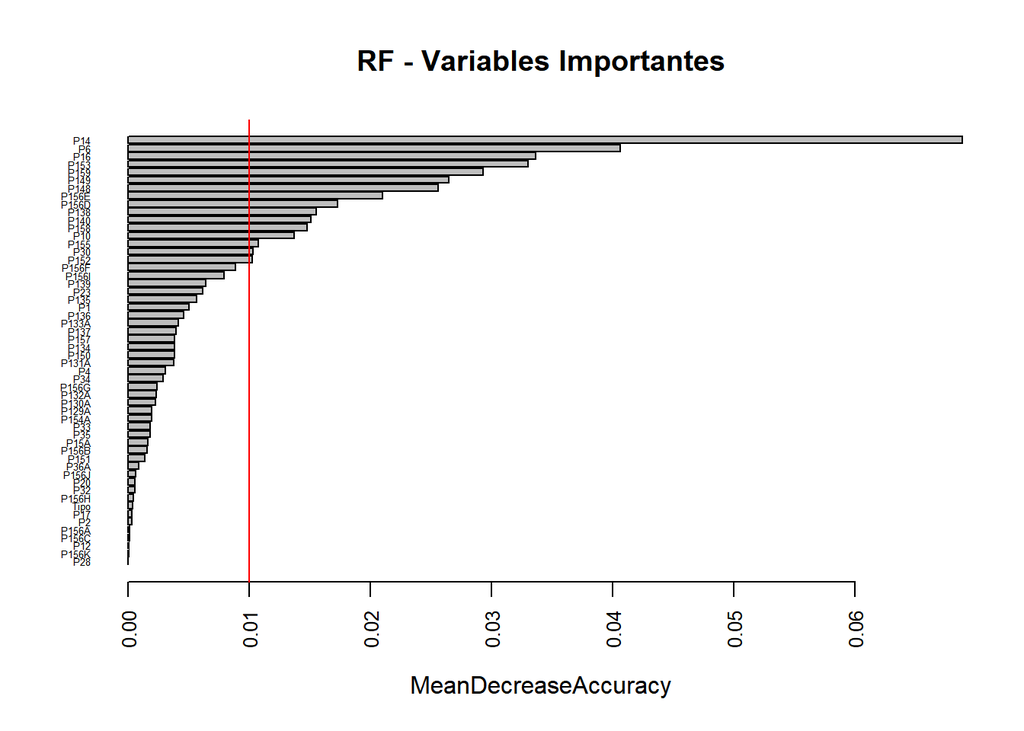

Filtrando aquellas variables que tienen una reducción promedio en la exactitud de predicción mayor a 0.01, identificamos las siguientes variables imporantes para la definición de los conglomerados.

```
##       MeanDecreaseAccuracy
## P14             0.06883702
## P6              0.04061848
## P16             0.03361939
## P153            0.03303252
## P159            0.02932124
## P149            0.02647323
## P148            0.02561235
## P156E           0.02097771
## P156D           0.01728703
## P138            0.01556413
## P140            0.01508431
## P158            0.01477315
## P10             0.01368472
## P155            0.01075884
## P30             0.01029748
## P152            0.01023634
```

## 3.3 Análisis de Conglomerados por K-Prototypes tomando variables importantes

Ahora volvemos a obtener conglomerados a partir de K-Prototypes considerando las variables importantes. En este caso podemos ver que el 56.59% de las observaciones pertenece al conglomerado 1, 11.96% al conglomerado 2 y 31.45% al conglomerado 3. Es importante notar que si bien se ha presentado una rotación en los conglomerados, aún se preserva una distribución de proporciones similar a la inicial, con una mayoria, una minoria y un intermedio.

```
## Estimated lambda: 1845168
```

```
##
##     1     2     3
## 56.59 11.96 31.45
```

Por otra parte, a fin de validar la seleccion de variables veamos el efecto en la exactitud de predicción considerando nuevamente un modelo Random Forest.

```
##
## clust.i_rf_f.hat    1    2    3
##                1 1466    7   79
##                2   16  300   12
##                3   79   23  786
```

```
## [1] "EP = 92.2"
```

Notemos que considerando las variables importantes de hecho se ha incrementado la exactitud en las predicciones. Esto se debe a que los nuevos conglomerados tienen mayor separación en sus características. Esto es, la pérdida en la exactiud de predicción por dejar de considerar variables menos importantes resulto menor a la ganancia por considerar variables que separan mejor a los conglomerados.

# 4. Análisis de resultados

Para el análisis de resultados previamente renombramos los conglomerados identificados. El conglomerado mayoría tendrá la etiqueta A, el conglomerado intermedio la etiqueta B y la minoría la etiqueta C.

```
##
##     A     B     C
## 56.59 31.45 11.96
```

## 4.1 Descripción de conglomerados respecto a las variables seleccionadas

En esta sección haremos una descripción de las variables que hallamos más importantes para la clasificación de los conglomerados y otras de interés dentro de la encuesta.

### 4.1.1 Costo del último televisor (P14)

En el análisis anterior pudimos observar que la variable que más aporta a la distinción entre los diferentes grupos, es el costo del último televisor que se compró en el hogar (P14). Respecto a esta variable podemos ver que las diferencias de los promedios entre los grupos son significativas, el grupo C gastó en promedio Bs 4.745, mientras que el grupo A y B gastaron en promedio Bs 1.622 y Bs 1.897, respectivamente.

```
## $A
##    Min. 1st Qu.  Median    Mean 3rd Qu.    Max.
##      70    1000    1500    1622    2000    5000
##
## $B
##    Min. 1st Qu.  Median    Mean 3rd Qu.    Max.
##     250    1390    1900    1897    2500    3630
##
## $C
##    Min. 1st Qu.  Median    Mean 3rd Qu.    Max.
##    2800    3500    4150    4745    5250   21000
```

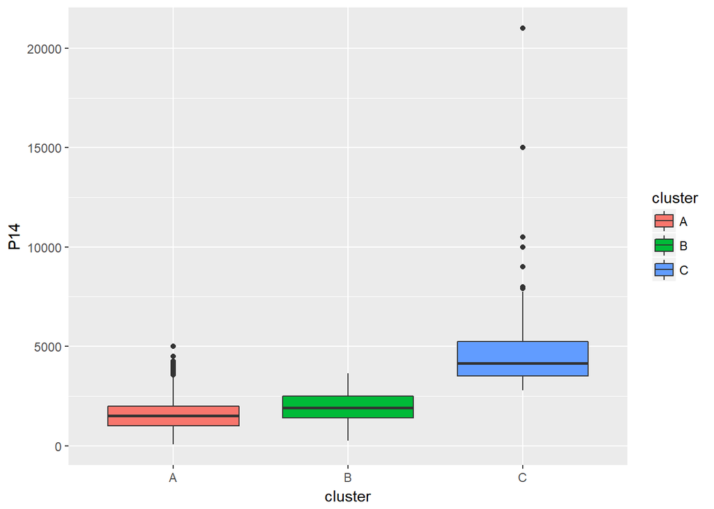

### 4.1.2 Tenencia de computadora de escritorio, computadora portátil o táblet en casa (P6)

Podemos observar claras diferencias entre el grupo A, respecto a los grupos B y C. Tenemos que tan solo el 23% de las personas del grupo A tienen computadoras de escritorio, portatiles o tables en su hogar, mientras que los grupos B y C los tienen en un 86% y 81%, respectivamente. Esto nos puede mostrar que la tenencia de estos bienes influye en que las personas de los grupos B y C tengan mayor facilidad de acceso al uso de la tecnología frente al grupo A.

```
##
##        A    B    C
##   1 0.23 0.86 0.81
##   2 0.77 0.14 0.19
```

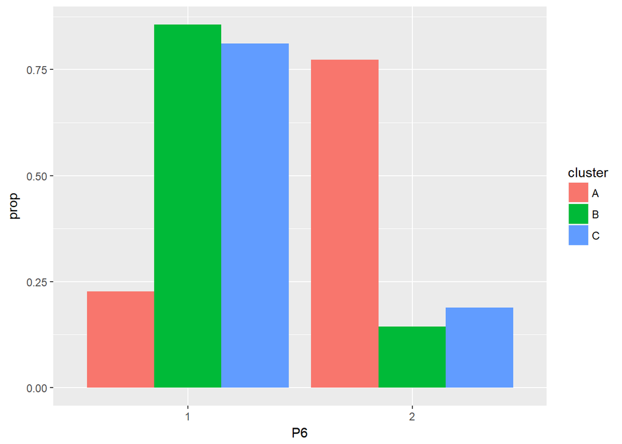

### 4.1.3 Tenencia de servicio de TV Cable (P16)

El comportamiento de la variable de tenencia de servicio de TV cable en el hogar tiene un comportamiento similiar. Se muestra que una minoria del grupo A (20%) tiene TV cable, frente a una mayoria para los grupos B y C (70% y 65%).

```
##
##        A    B    C
##   1 0.11 0.22 0.08
##   2 0.45 0.10 0.04
```

```
##
##        A    B    C
##   1 0.20 0.70 0.65
##   2 0.80 0.30 0.35
```

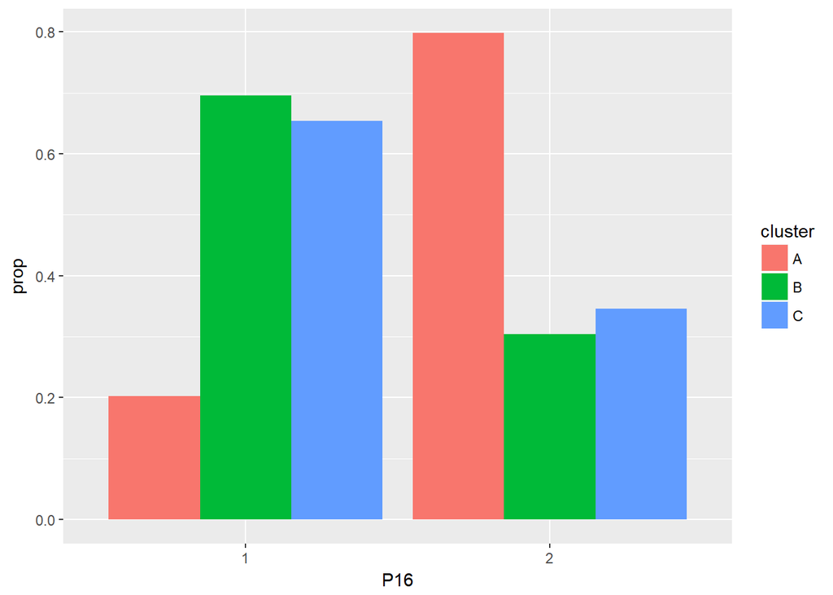

### 4.1.4 Nivel de instrucción del jefe de hogar (P153)

En lo que concierne al nivel de instrucción del jefe del hogar podemos observar una concentración importante diferenciada por grupos. En el caso del grupo A esta concentración está en las categorías de primaria o menos, secundaria incompleta y secundaria completa (1,2,3) llegando a representar el 73% de las personas del grupo A, con el 30% de las personas de este grupo donde el(la) jefe(a) de hogar tiene la secundaria completa. Mientras que en los grupos B y C el jefe de hogar con mayor frecuencia tiene la universidad completa, representando el aproximadamente el 29% para los 2 grupos.

```
##
##        A    B    C
##   1 0.14 0.02 0.01
##   2 0.11 0.02 0.01
##   3 0.17 0.06 0.02
##   4 0.08 0.05 0.01
##   5 0.01 0.02 0.01
##   6 0.03 0.03 0.01
##   7 0.02 0.09 0.03
##   8 0.00 0.02 0.01
```

```
##
##        A    B    C
##   1 0.24 0.07 0.08
##   2 0.19 0.08 0.09
##   3 0.30 0.20 0.19
##   4 0.15 0.17 0.12
##   5 0.02 0.05 0.05
##   6 0.05 0.09 0.09
##   7 0.04 0.29 0.29
##   8 0.00 0.06 0.10
```

```
##
##        A    B    C
##   1 0.82 0.13 0.06
##   2 0.75 0.17 0.08
##   3 0.67 0.24 0.09
##   4 0.55 0.35 0.10
##   5 0.39 0.45 0.16
##   6 0.45 0.40 0.15
##   7 0.14 0.63 0.23
##   8 0.07 0.55 0.37
```

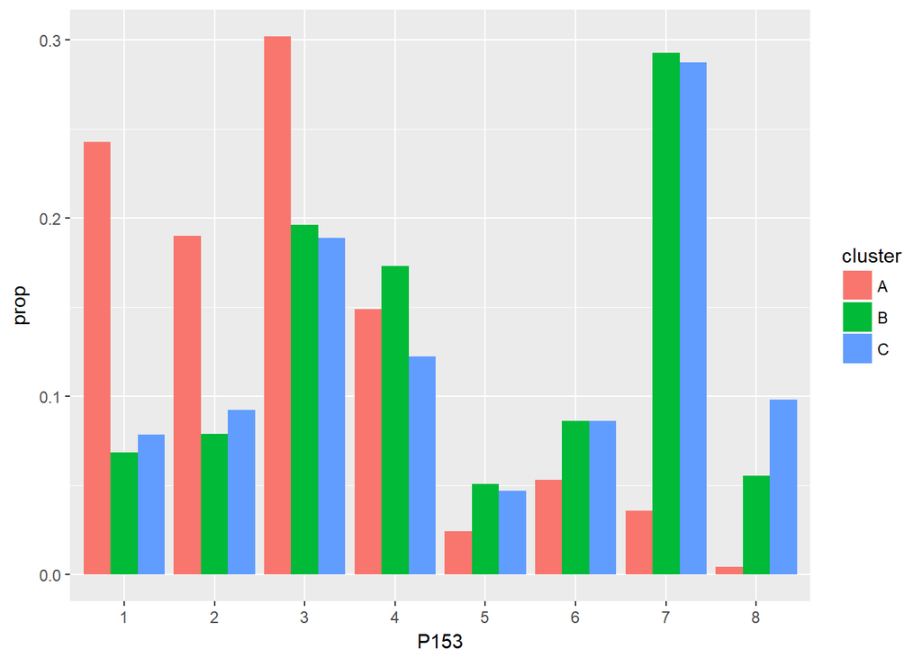

### 4.1.5 Tipo de localidad (P159)

```
##
##        A    B    C
##   1 0.18 0.25 0.08
##   2 0.16 0.05 0.03
##   3 0.23 0.02 0.01
```

```
##
##        A    B    C
##   1 0.32 0.79 0.69
##   2 0.28 0.16 0.23
##   3 0.40 0.05 0.09
```

```
##
##        A    B    C
##   1 0.36 0.48 0.16
##   2 0.67 0.22 0.11
##   3 0.90 0.06 0.04
```

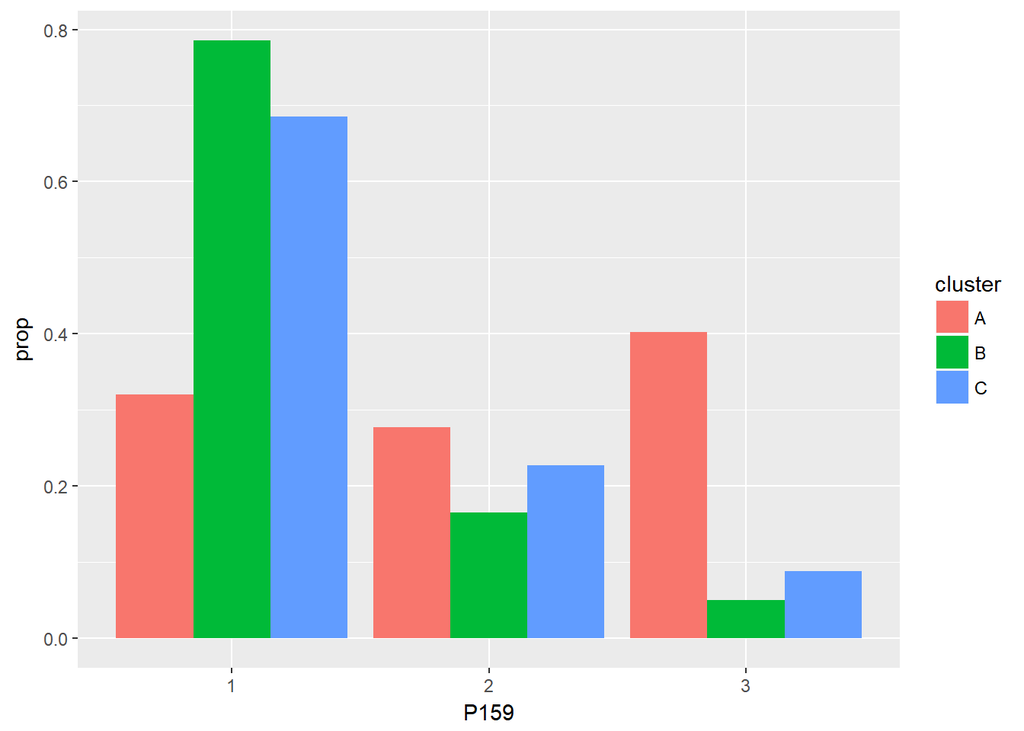

### 4.1.6 Nivel de instrucción del entrevistado (P149)

Respecto al nivel de instrucción del entrevistado podemos observar que la mayoría del grupo A tiene la secundaria incompleta (30%) o la secundaria completa (28%). Por otra parte la mayoría del grupo B tiene la secundaria completa (24%) o la universidad incompelta (24%). Finalmente la mayoria del grupo C tiene la universidad incompleta (28%) o la universidad completa (20%).

```
##
##        A    B    C
##   1 0.06 0.00 0.00
##   2 0.17 0.04 0.02
##   3 0.16 0.08 0.02
##   4 0.06 0.04 0.01
##   5 0.01 0.01 0.00
##   6 0.08 0.07 0.03
##   7 0.02 0.07 0.02
##   8 0.00 0.01 0.01
```

```
##
##        A    B    C
##   1 0.11 0.01 0.02
##   2 0.30 0.12 0.14
##   3 0.28 0.24 0.14
##   4 0.10 0.12 0.12
##   5 0.01 0.02 0.02
##   6 0.15 0.24 0.28
##   7 0.04 0.21 0.20
##   8 0.00 0.04 0.07
```

```
##
##        A    B    C
##   1 0.92 0.05 0.03
##   2 0.76 0.17 0.08
##   3 0.63 0.30 0.07
##   4 0.52 0.35 0.13
##   5 0.47 0.40 0.13
##   6 0.44 0.39 0.17
##   7 0.20 0.58 0.22
##   8 0.04 0.54 0.41
```

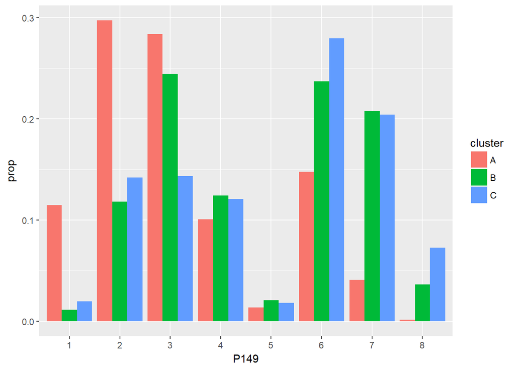

### 4.1.7 Sexo (P148)

Del total de datos en la encuesta el 50% se la realizó a hombres, y otro 50% a mujeres, pero en nuestra clasificación por categorías podemos observar que hay diferencias, no tan grandes, pero estas existen. por ejemplo el grupo A esta en su mayoria compuesto por mujeres, llegando a representar el 58% del grupo. El grupo que tiene más diferencias es el B, con 62% de hombres frente a un 38% de mujeres. Mientras que el grupo C tiene el comportamiento inverso al de A, en este el 59% son hombres y un 41% son mujeres.

```
##
##        A    B    C
##   1 0.24 0.19 0.07
##   2 0.33 0.12 0.05
```

```
##
##        A    B    C
##   1 0.42 0.62 0.59
##   2 0.58 0.38 0.41
```

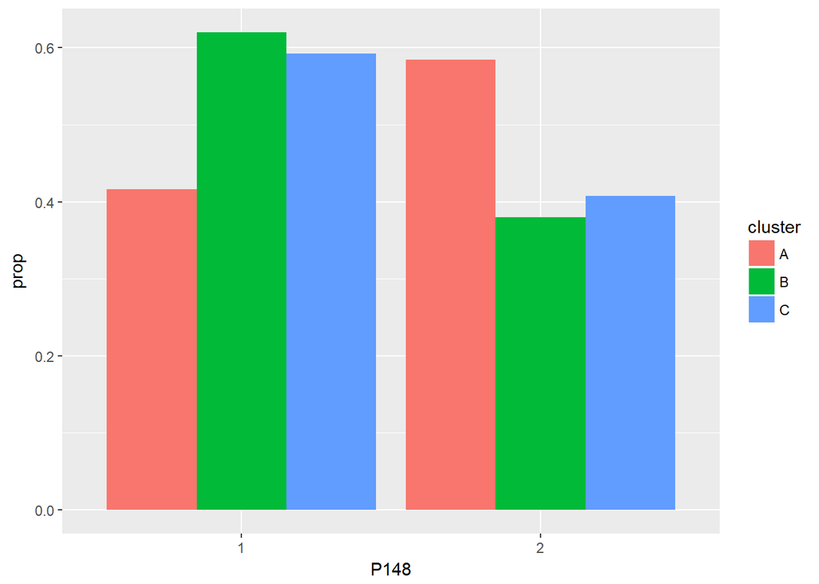

### 4.1.8 Tenencia de microondas (P156E)

Siguiendo la línea de la tenencia de bienes podemos observar claramente las diferencias que existen entre los grupos. Del total de la encuesta tan solo el 22% de los hogares tienen microndas, y haciendo la división por grupos, tenemos que el 94% de las personas del grupo A no poseen microondas, mientras que en los grupos B y C las diferencias entre los que poseen microondas y los que no, no son tan grandes, llegando a 22 y 6 puntos porcentuales, frente a la diferencia de 88 puntos porcentuales del grupo A.

```
##
##        A    B    C
##   1 0.04 0.12 0.06
##   2 0.53 0.19 0.06
```

```
##
##        A    B    C
##   1 0.06 0.39 0.47
##   2 0.94 0.61 0.53
```

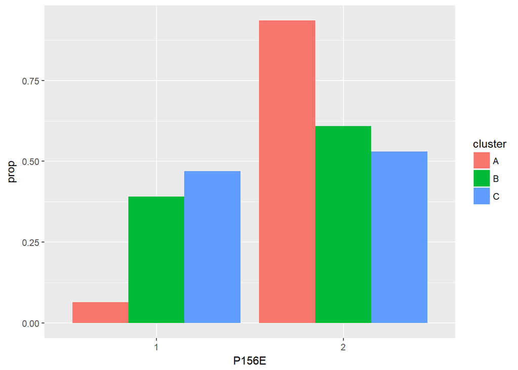

### 4.1.9 Tenencia de lavadora de ropa (P156D)

Respecto a la lavaroda de ropa, el comportamiento es similar, la gran mayoría de las personas del grupo A no tienen lavadora de ropa (90%) mientras que los grupos B y C si poseen este bien, con un 61% y 54% de hogares que poseen lavadora de ropa, respectivamente.

```
##
##        A    B    C
##   1 0.06 0.19 0.06
##   2 0.51 0.12 0.06
```

```
##
##        A    B    C
##   1 0.10 0.61 0.54
##   2 0.90 0.39 0.46
```

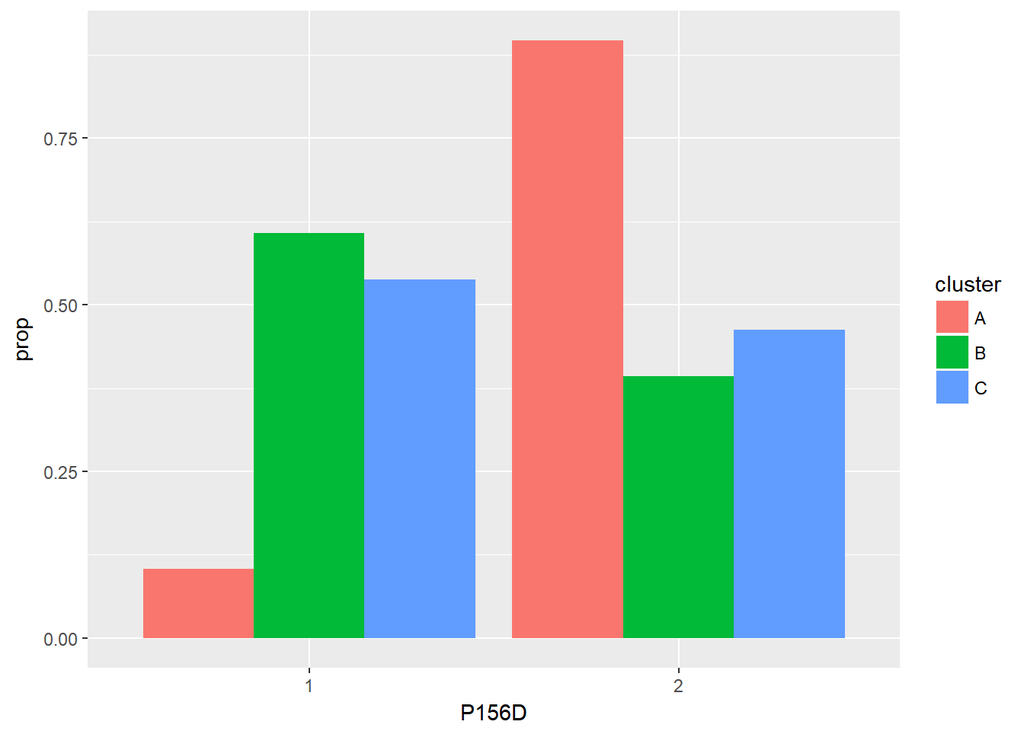

### 4.1.10 Consideración de medio más imparcial (P138)

Podemos observar que para los 3 grupos el medio de comunicación más imparcial es la TV, con proporciones de los grupos entre 41 y 30 porciento. Al mismo tiempo podemos observar que el grupo C es el más escéptico respecto a la imparcialidad de los medios de comunicación, siendo que el 20% de este grupo considera que ningún medio de comunicación es imparcial.

```
##
##        A    B    C
##   1 0.23 0.10 0.04
##   2 0.12 0.05 0.02
##   3 0.07 0.05 0.01
##   4 0.02 0.02 0.01
##   5 0.03 0.03 0.01
##   6 0.04 0.03 0.01
##   7 0.06 0.04 0.02
```

```
##
##        A    B    C
##   1 0.41 0.30 0.31
##   2 0.22 0.17 0.17
##   3 0.12 0.14 0.11
##   4 0.03 0.06 0.07
##   5 0.05 0.09 0.06
##   6 0.07 0.10 0.08
##   7 0.11 0.14 0.20
```

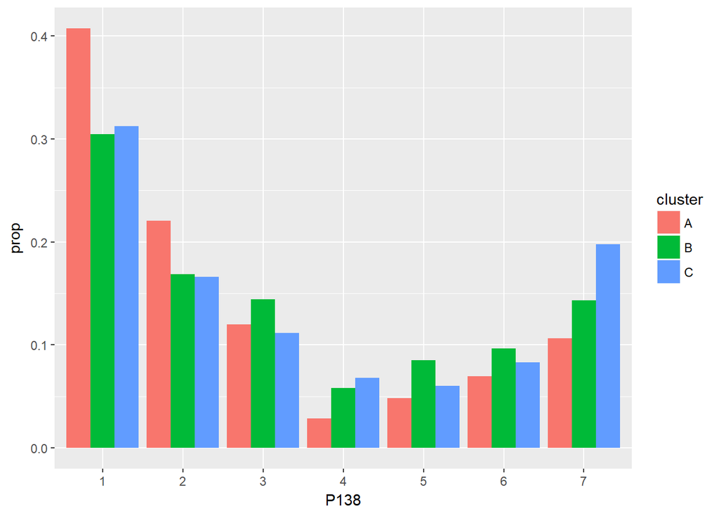

### 4.1.11 Consideración de medio más abierto a la participación (P140)

La mayoría de las personas del grupo A consideran a la televisión como el medio de comunicación más participativo, mientras que los grupos B y C tienen una clara preferencia por las redes sociales. Es interesante observar la interacción que tienen las personas con los medios y lo imparciales que creen que son. en este caso, si bien las redes sociales son las más participativas ocupaban el cuarto lugar en la escala de medios imparciales.

```
##
##        A    B    C
##   1 0.21 0.06 0.03
##   2 0.13 0.05 0.02
##   3 0.01 0.01 0.01
##   4 0.01 0.01 0.00
##   5 0.03 0.03 0.01
##   6 0.14 0.13 0.04
##   7 0.03 0.02 0.01
```

```
##
##        A    B    C
##   1 0.37 0.19 0.22
##   2 0.22 0.17 0.18
##   3 0.02 0.04 0.06
##   4 0.02 0.04 0.02
##   5 0.06 0.08 0.09
##   6 0.25 0.41 0.36
##   7 0.06 0.07 0.08
```

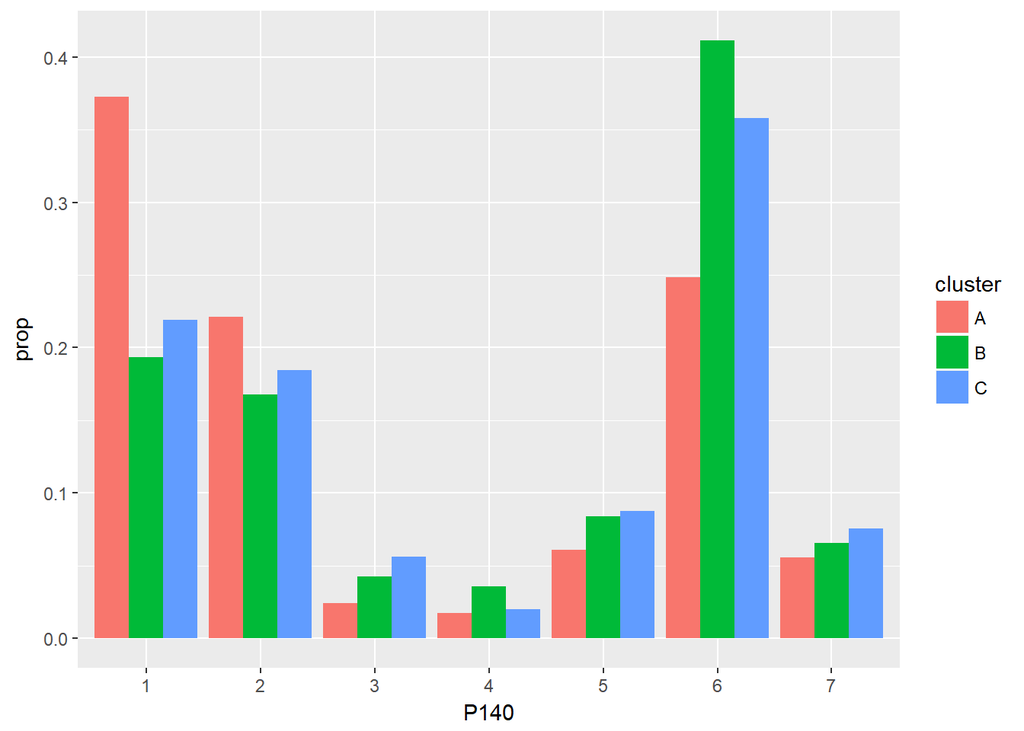

### 4.1.12 Departamento (P158)

Podemos notar una concentración importante del grupo C en La Paz (22%), Cochabamba (15%) y Pando(13%), mientras que los demás grupos están distribuidos de manera más regular entre todos los departamentos.

```
##
##        A    B    C
##   1 0.06 0.03 0.03
##   2 0.06 0.04 0.01
##   3 0.06 0.03 0.02
##   4 0.09 0.03 0.01
##   5 0.05 0.04 0.01
##   6 0.07 0.03 0.01
##   7 0.05 0.04 0.01
##   8 0.07 0.02 0.01
##   9 0.05 0.05 0.02
```

```
##
##        A    B    C
##   1 0.11 0.10 0.22
##   2 0.11 0.13 0.09
##   3 0.10 0.10 0.15
##   4 0.16 0.10 0.09
##   5 0.09 0.12 0.07
##   6 0.13 0.10 0.10
##   7 0.09 0.11 0.09
##   8 0.12 0.07 0.07
##   9 0.09 0.16 0.13
```

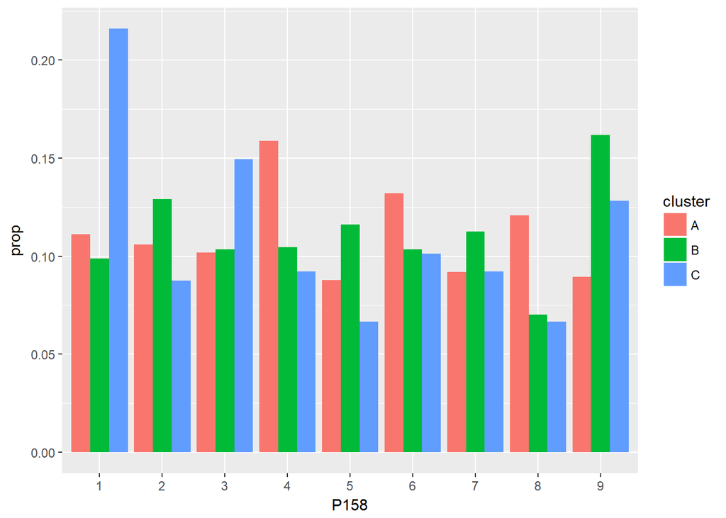

### 4.1.13 Días a la semana de uso de computadora de escritorio, computadora portátil o táblet(P10)

El comportamiento de los otros grupos es cualitativamente diferente, ya que estos estan más “conectados”. En el grupo C, el 62% de las personas utilizan estos equipos entre 3 a 7 días a la semana, siendo que el 31% de las personas del grupo C los usan todos los días. El grupo B tiene un comportamiento similar pero con valores un poco más bajos, el 58% de las personas del grupo B utilizan estos equipos entre 3 a 7 días a la semana, con un 22% de personas que los usan todos los días.

Este comportamiento nos hace pensar que las personas del grupo C son aquellas que más interactuan con las TICS.

```
##
##        A    B    C
##   1 0.03 0.02 0.01
##   2 0.04 0.03 0.01
##   3 0.03 0.04 0.01
##   4 0.02 0.03 0.01
##   5 0.02 0.03 0.01
##   6 0.01 0.02 0.01
##   7 0.01 0.07 0.04
##   8 0.04 0.04 0.01
##   9 0.38 0.04 0.02
```

```
##
##        A    B    C
##   1 0.05 0.05 0.07
##   2 0.06 0.11 0.08
##   3 0.05 0.12 0.11
##   4 0.03 0.08 0.06
##   5 0.03 0.10 0.08
##   6 0.01 0.06 0.06
##   7 0.03 0.22 0.31
##   8 0.07 0.12 0.08
##   9 0.68 0.13 0.16
```

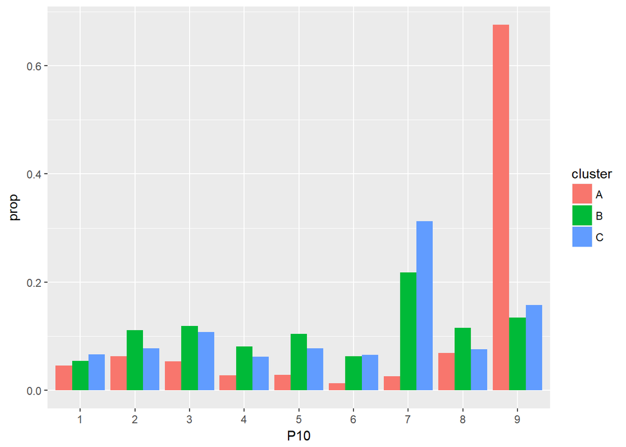

### 4.1.14 Ingreso mensual promedio en el hogar (P155)

Viendo la distribución de los ingresos mensuales promedio declarados en la encuesta, podemos ver que el grupo A tiene una concentración en las 2 primeras categorías, es decir el 79% de los hogares del grupo A tienen un ingreso mensual promedio de Bs 3500 o menos. En este mismo intervalo, los grupos B y C concentran el 46% y 40% respectivamente, lo cual es significativamente menor. Entre los grupos B y C podemos observar que el intervalo donde estan mayormente concentrados es el de Bs 3.501 a Bs 5.000 representando el 33% del grupo B y el 28% del grupo C.

Además, en los ingresos más altos, en el intervalo de más de Bs 5.001 el grupo B agrupa el 21 % de sus integrantes, mientras que el grupo C en el mismo intervalo tiene un 31% de personas.

```
##
##        A    B    C
##   1 0.18 0.05 0.02
##   2 0.27 0.09 0.03
##   3 0.08 0.10 0.03
##   4 0.03 0.04 0.02
##   5 0.01 0.02 0.01
##   6 0.00 0.01 0.01
##   7 0.00 0.00 0.00
##   8 0.00 0.00 0.00
```

```
##
##        A    B    C
##   1 0.31 0.16 0.15
##   2 0.48 0.30 0.25
##   3 0.14 0.33 0.28
##   4 0.05 0.13 0.15
##   5 0.02 0.05 0.10
##   6 0.00 0.02 0.05
##   7 0.00 0.01 0.01
##   8 0.00 0.00 0.00
```

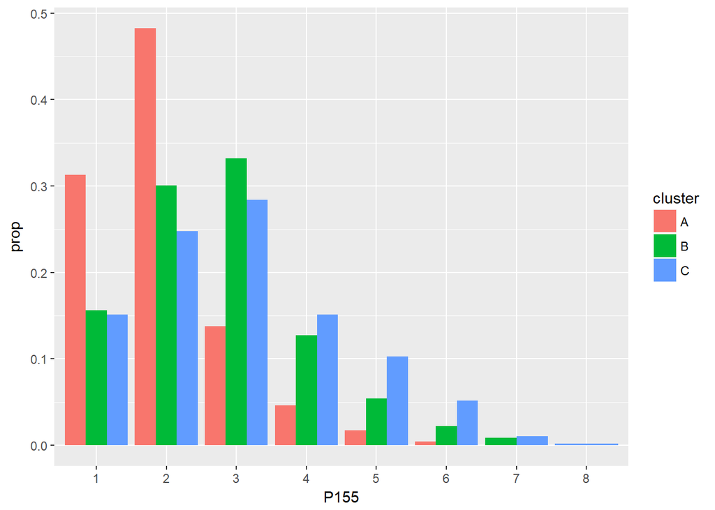

### 4.1.15 Costo último celular (P30)

```
## $A
##    Min. 1st Qu.  Median    Mean 3rd Qu.    Max.
##    10.0   500.0   800.0   862.9  1100.0  8001.0
##
## $B
##    Min. 1st Qu.  Median    Mean 3rd Qu.    Max.
##      60     800    1200    1346    1700    4200
##
## $C
##    Min. 1st Qu.  Median    Mean 3rd Qu.    Max.
##     100     900    1500    1591    2000    4200
```

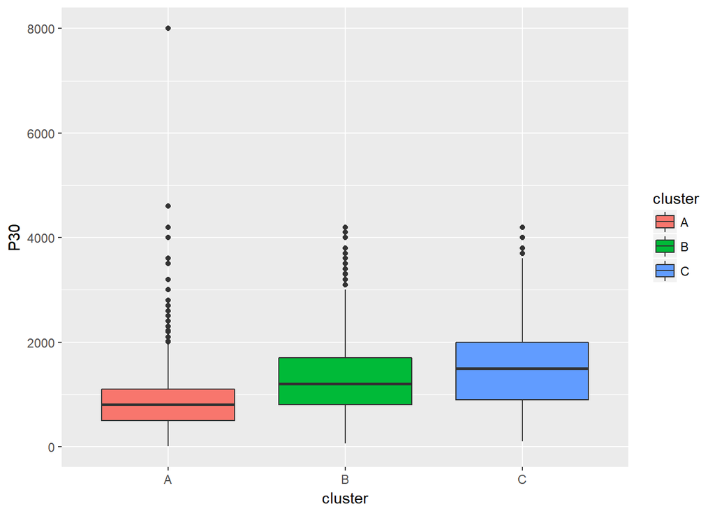

### 4.1.16 Categoría ocupacional (P152)

La conformación de los grupos en base a la categoría ocupacional, nos muestra que los 3 grupos estan compuestos en su mayoría por estudiantes (A 27%, B 30%, C 28%). Al mismo tiempo es interesante ver algunas diferencias que existen entre los grupos respecto a algunas categorías ocupacionales. Por ejemplo para los trabajadores por cuenta propia el grupo A tiene al 18% de sus integrantes, contra un 12% para los grupos B y C, viendo una diferencia significativa. De manera similar una categoría ocupacional que diferencia a los grupos es justamente la de profesional independiente, donde el grupo A cuenta con solo el 1% de sus miembros, mientras que el B y C tienen al 8 y 9 porciento de las personas respectivamente. Al mismo tiempo es interesante ver que para el grupo A la categoría de ama de casa representa al 16% de las entrevistadas, que es significativamente diferente a los otros grupos. Esta composición puede servirnos para explicar las diferencias en la estructura por sexos entre los grupos.

```
##
##         A    B    C
##   AS 0.10 0.08 0.03
##   CP 0.10 0.04 0.01
##   NP 0.08 0.05 0.02
##   PI 0.01 0.02 0.01
##   EM 0.01 0.00 0.00
##   ES 0.15 0.09 0.03
##   AC 0.09 0.02 0.00
##   RJ 0.01 0.00 0.00
##   SB 0.02 0.01 0.00
##   SN 0.00 0.00 0.00
```

```
##
##         A    B    C
##   AS 0.18 0.25 0.26
##   CP 0.18 0.12 0.12
##   NP 0.13 0.15 0.15
##   PI 0.01 0.08 0.09
##   EM 0.01 0.01 0.01
##   ES 0.27 0.30 0.28
##   AC 0.16 0.06 0.04
##   RJ 0.02 0.01 0.02
##   SB 0.03 0.03 0.01
##   SN 0.01 0.00 0.01
```

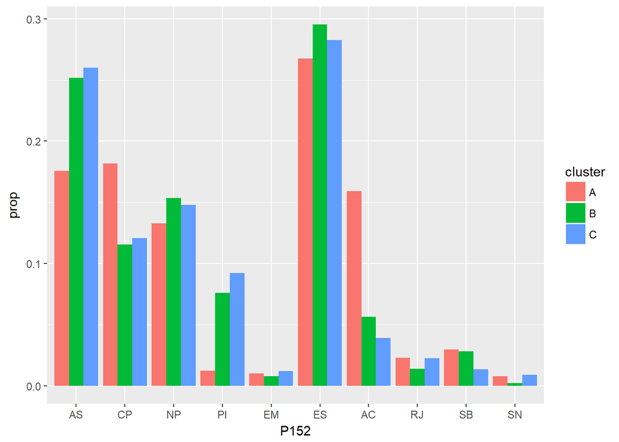

## 4.2 Descripción de conglomerados respecto a otras variables de interés

En la subsección anterior vimos algunas diferencias de las características y comportamientos de los grupos, principalmente con aquellas variables que se identificaron como importantes al momento de hacer la clasificación por K-Prototypes. Ahora vamos a analizar el comportamiento con otras variables de interés.

### 4.2.1 Edad (P1)

Como se puede observar en la gráfica, las edades promedio de los grupos son muy parecidas, rondan los 32 años, lo que nos muestra que tienen una estructura demográfica parecida. Al mismo tiempo, alguna de las diferencias que podemos obtener al observar los histogramas de las edades de cada grupo, es que dentro del grupo A hay más personas de más de 70 años, mientras que en los grupos B y C, este grupo etario es más reducido.

```
## $A
##    Min. 1st Qu.  Median    Mean 3rd Qu.    Max.
##   14.00   21.00   29.00   33.16   44.00   90.00
##
## $B
##    Min. 1st Qu.  Median    Mean 3rd Qu.    Max.
##   14.00   22.00   30.00   31.86   40.00   71.00
##
## $C
##    Min. 1st Qu.  Median    Mean 3rd Qu.    Max.
##   14.00   22.00   30.00   32.03   40.00   82.00
```

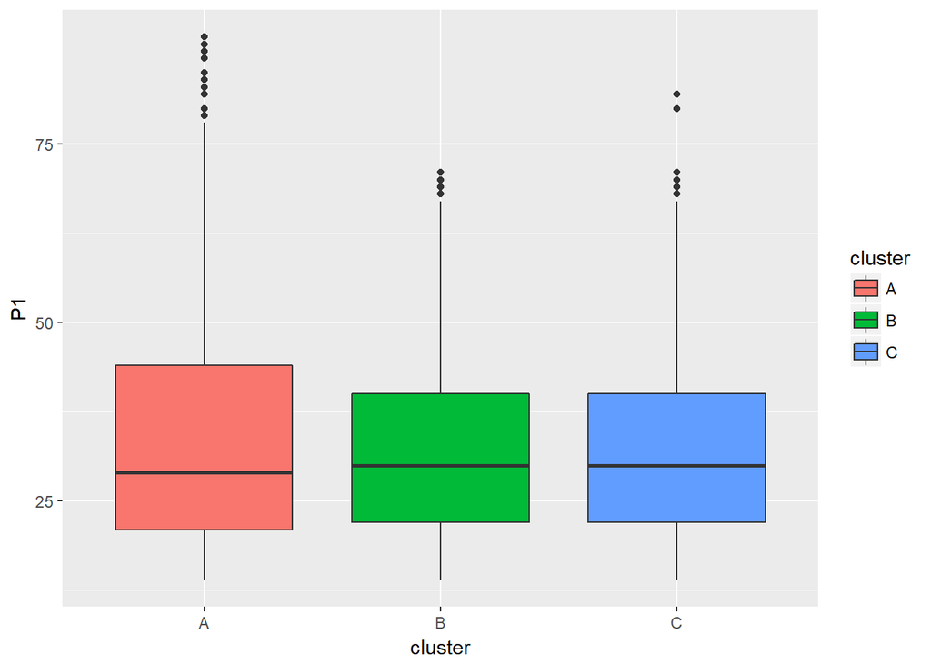

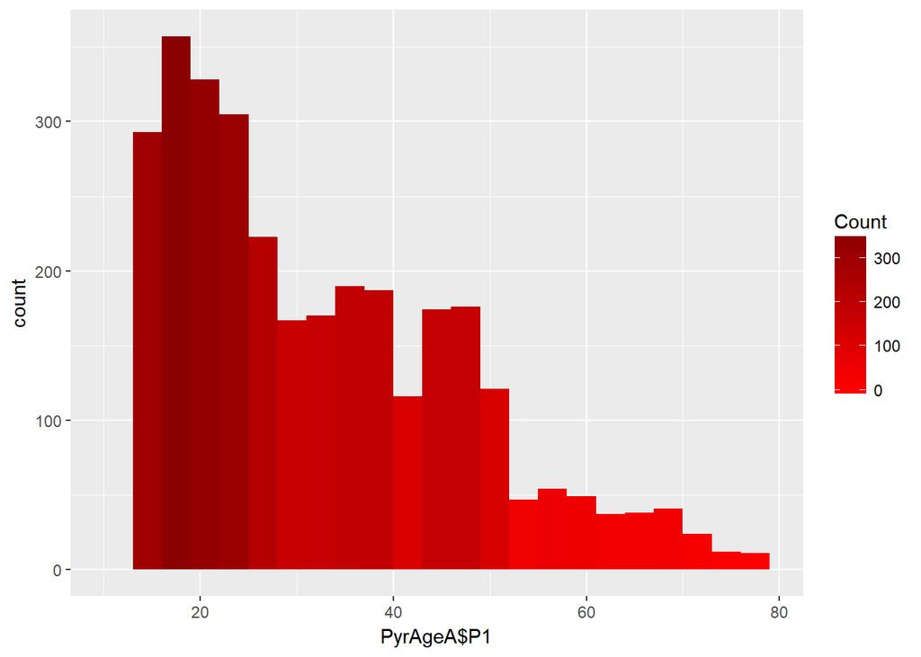

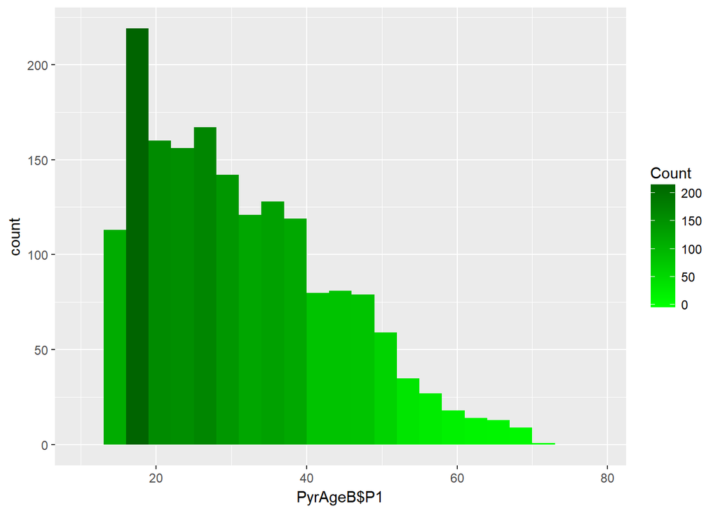

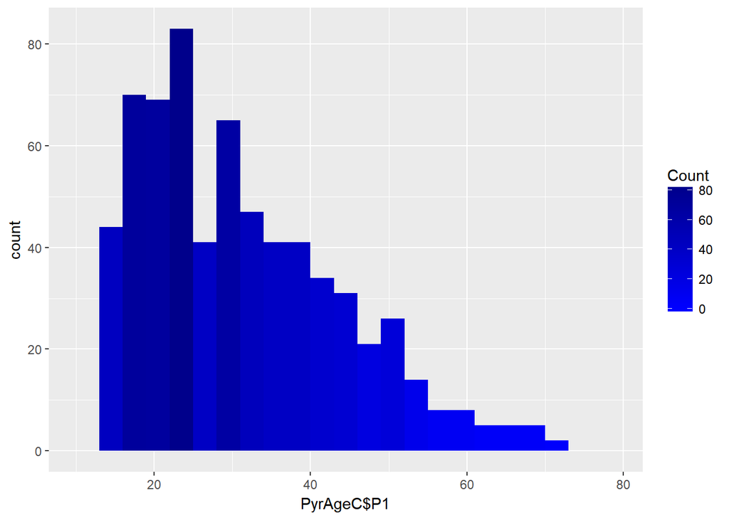